# Data prep for *Practice Changes at U.S. Transplant Centers After the New Adult Heart Allocation Policy*

Kevin Chung, William Parker

# Loading in packages

This chunk is used to load in the packages in R that help us to tidy, manipulate, and visualize the data.

```r
library(tidyverse)
library(haven)
library(rmdformats)
```

# Data sources

## Standard Scientific Registry of Transplant Recipients (SRTR) SAF files

We uploaded all the relevant files that contained data for the study.

```r
# read in the SRTR SAF files
cand_thor <- read_sas("cand_thor.sas7bdat", NULL) %>%
  zap_formats() %>% zap_labels()

statjust_hr1a <- read_sas("statjust_hr1a.sas7bdat", NULL) %>%
  zap_formats() %>% zap_labels()

statjust_hr1b <- read_sas("statjust_hr1b.sas7bdat", NULL) %>%
  zap_formats() %>% zap_labels()

tx_hr <- read_sas("tx_hr.sas7bdat", NULL) %>%
  zap_formats() %>% zap_labels()
```

## Special status 1-6 justification files

This file upload contained all the new priority system justification form information. The reason why this is a separate file upload is because the new priority system data were sent by SRTR in a different format than the old priority system data.

```r
file_list <- list.files(path="stat_1_6")

for (i in 1:length(file_list)){
  name <- substr(file_list[[i]], 1, nchar(file_list[[i]])-4)

  path <- paste0("stat_1_6/", file_list[[i]])

  assign(name, read_delim(path, delim = "|"))
}
```

# Select study sample

## Define data ranges

This section specifics the dates used in the study. The dates can be modified by changing the date in this chunk of code. The only constraint is that the start date must be after 10-18-2017 to work properly to generate even cohorts.

```r
#
start_date <- as.Date("2017-12-1")

end_date <- as.Date("2019-4-30")

#mark the end of the pre-policy cohort
pre_policy_end_date <- end_date - lubridate::years(1)

#mark the start of the post-policy cohort
transition_date <- start_date + lubridate::years(1)

policy_switch_date <- as.Date("2018-10-18")

multi <- TRUE #keeping multi-organ recipients so we can code them as Status 5 in the pre-policy period
peds <- FALSE # exclude candidates < 18 at the time of listing
```

## Filter initial listings accordingly

We have filtered the data to only include data for active adult heart transplant recipients.

```r
init_list <- cand_thor %>%
  mutate(list_date = CAN_LISTING_DT) %>%
    filter(list_date >= start_date & list_date <= end_date & WL_ORG == "HR")  %>%
  mutate(status = CAN_INIT_STAT,
         OPO = CAN_LISTING_OPO_ID,
         date_start = list_date)

#remove peds
if (peds == FALSE){
    init_list <- init_list %>% filter(CAN_AGE_AT_LISTING >17)
    tot_adults <- nrow(init_list)
}

#keep multiorgan recipients
if (multi == FALSE){

    multi_recips <- tx_hr %>% filter(REC_TX_TY == 2 | REC_TX_TY ==4) %>% select(PX_ID,REC_TX_TY)

    n_mults <- nrow(init_list %>% filter(PX_ID %in% multi_recips$PX_ID))

    init_list <- init_list %>% filter(!PX_ID %in% multi_recips$PX_ID)

    remove(multi_recips)
}


#filter out inactives
init_list <- init_list %>%
  filter(CAN_INIT_STAT %in% c(2010, 2020, 2030, 1110, 1120, 1130, 1140, 1150, 1160, 2110, 2120, 2130, 2140, 2150, 2160))
```

# Classify pre-policy listings as Status 1-6

We reclassified the pre-policy cohort into the new priority system tiers. Following the approach taken during OPTN simulation modeling, we assigned each candidate in the pre-policy cohort a status by applying the new heart allocation policy retrospectively based on the candidate’s old priority system status justification, listing diagnosis, and hemodynamics.

## Status 1A -> Status 1-4

```r
#select pre-policy listings
status_1a <- init_list %>% filter(list_date < policy_switch_date & CAN_INIT_STAT == 2010)


just_1a <- statjust_hr1a %>%
    filter(PX_ID %in% status_1a$PX_ID) %>%
    arrange(PX_ID, CANHX_CHG_DT)

#remove redundant or erroneous justifications
just_1a <- distinct(just_1a) %>%
  filter(CANHX_FORM_STAT == 4 | CANHX_FORM_STAT == 8) %>%
  distinct(PX_ID, CANHX_CHG_DT, .keep_all = TRUE)


#select key variables
just_1a <- just_1a %>% select(PX_ID, CAN_LISTING_CTR_ID, CANHX_CHG_DT,
    CANHX_STAT_TY, CANHX_FORM_STAT,
    CANHX_DIALYSIS, CANHX_LAB_SERUM_CREAT,
    CANHX_ADULT_CRITERIA_A, CANHX_ADULT_CRITERIA_B,
  CANHX_ADULT_CRITERIA_C, CANHX_ADULT_CRITERIA_D,
  CANHX_ADULT_CRITERIA_E, CANHX_INTRP_DOBU, CANHX_INTRP_DOPA, CANHX_INTRP_MILRIN,
    CANHX_ADMITTED,
    CANHX_IABP, CANHX_ECMO, CANHX_LVAD_TYPE, CANHX_VAD, CANHX_TAH, CANHX_RVAD_TYPE,
    CANHX_LAB_BILI,
    CANHX_HEMO_SBP, CANHX_CARD_OUTPUT, CANHX_HEMO_CI, CANHX_HEMO_INTRP_OBTAINED, CANHX_HEMO_BSA,
    CANHX_HEMO_PCWP,
    CANHX_HEMO_MPAP,
    CANHX_DEV_MALFUNCTN,
    CANHX_DEV_VENT_ARRYTHM, CANHX_PHYS_HR_RHYTH,CANHX_DEV_INFECT
    ) %>% left_join(cand_thor %>% select(PX_ID, CAN_PCW_MEAN, CAN_HGT_CM, CAN_WGT_KG, CAN_CARDIAC_OUTPUT, CAN_CARDIAC_OUTPUT_MEDS)) #adding back select cand_thor hemodynamics

#durable LVAD list for elective 1A time
#lvad_list <- c(205, 206, 208, 210, 216, 217, 223, 224, 230, 231, 232, 233)
durable_list <- c(205, 206, 208, 210, 216, 217, 223, 224, 230, 231, 232, 233,
                  305, 306, 313, 316, 319, 325, 402)

#non dischargable VADs
non_discharge <- c(201, 203, 204, 209, 215, 218, 221, 222, 225, 226, 227, 228,
                   234, 301, 302, 303, 309, 310, 311, 320, 321)

just_1a <- just_1a %>%
  mutate(status = "Status 1A",
         stat_just = case_when(
    CANHX_ADULT_CRITERIA_A ==1~ "Status 1A (MCS for shock)",
    CANHX_ADULT_CRITERIA_B == 1 ~ "Status 1A (MCS complication)",
    CANHX_ADULT_CRITERIA_C == 1 ~ "Status 1A (Mechanical ventilation)",
    CANHX_ADULT_CRITERIA_D == 1 ~ "Status 1A (High dose inotropes)",
    CANHX_ADULT_CRITERIA_E == 1 ~ "Status 1A (Exception)"
  ),
  ino_ci = as.numeric(CANHX_HEMO_CI),
    ino_pcwp = as.numeric(CANHX_HEMO_PCWP),
  n_inos = ifelse(is.na(CANHX_INTRP_DOPA)==FALSE, 1, 0) +
    ifelse(is.na(CANHX_INTRP_DOBU)==FALSE, 1, 0) +
    ifelse(is.na(CANHX_INTRP_MILRIN)==FALSE, 1, 0),
  n_inos = ifelse(status != 2010, NA, n_inos),
    multi_ino = ifelse(n_inos > 1, 1, 0),
    single_ino = ifelse(n_inos ==1, 1, 0),
    low_d_ino = ifelse(n_inos> 1 &
               (CANHX_INTRP_DOPA<3 | CANHX_INTRP_MILRIN <0.25 | CANHX_INTRP_DOBU < 3), 1, 0),
    low_s_ino = ifelse(n_inos ==1 & (CANHX_INTRP_MILRIN <0.5 | CANHX_INTRP_DOBU < 7.5),1,0),
    bsa = 0.007184*(CAN_HGT_CM)^(0.725)*CAN_WGT_KG^(0.425),
    tcr_ci = CAN_CARDIAC_OUTPUT/bsa,
    iabp_no_shock = case_when(
      tcr_ci > 1.8 & CAN_CARDIAC_OUTPUT_MEDS == "N" & (CANHX_IABP==1) ~ 1,
      tcr_ci > 2.0 & (CANHX_IABP==1) ~ 1,
      CAN_PCW_MEAN < 15 & CANHX_IABP ==1 ~ 1,
      is.na(tcr_ci) == FALSE & (CANHX_IABP==1) ~ 0
    ),
  dopa_dose = CANHX_INTRP_DOPA,
  dobu_dose = CANHX_INTRP_DOBU,
  milrin_dose = CANHX_INTRP_MILRIN,
    overtreat = case_when(
      ##Note absence of SBP requirement- patients were on inotropes
        iabp_no_shock == 1 ~ 1,
        CANHX_HEMO_PCWP < 15 & CANHX_ADULT_CRITERIA_D ==1 ~ 1,
        ino_ci>2.2~ 1,
        ino_pcwp <15 ~ 1,
        (ino_ci>1.8 & CANHX_HEMO_INTRP_OBTAINED =="N") ~ 1,
        low_d_ino == 1 | low_s_ino == 1 ~ 1,
        ino_ci <= 1.8 ~ 0,
        (ino_ci <= 2.2 & CANHX_HEMO_INTRP_OBTAINED =="Y") ~ 0,
        TRUE ~ 0
    ),
  elective_1A = case_when(
    CANHX_ADULT_CRITERIA_A ==1 & CANHX_IABP ==0 & CANHX_ECMO ==0 & CANHX_LVAD_TYPE %in% durable_list ~1,
    TRUE ~ 0),
  Justification = case_when(
    CANHX_ADULT_CRITERIA_E ==1  ~ "Status 3- Exception",
    CANHX_ADULT_CRITERIA_C == 1 ~ "Status 3- Vent",
    CANHX_DEV_VENT_ARRYTHM == 1 & CANHX_ADULT_CRITERIA_B ==1 ~ "Status 1-MSCD with Life Threatening Arrhythmia",
    CANHX_ECMO == 1 ~ "Status 1-VA ECMO",
    CANHX_ADULT_CRITERIA_A ==1 & CANHX_VAD == 1 & is.na(CANHX_RVAD_TYPE)== FALSE & (CANHX_LVAD_TYPE %in% non_discharge)~ "Status 1-Non-Dischargeable BiVAD",
    CANHX_VAD == 1 & CANHX_LVAD_TYPE %in% non_discharge ~ "Status 2-Non-Dischargeable LVAD",
    CANHX_DEV_MALFUNCTN == 1 ~ "Status 2-MSCD Device with Malfunction",
    CANHX_ADULT_CRITERIA_A ==1 & CANHX_IABP ==0 & elective_1A==0  ~ "Status 2-Other MSCD",
    CANHX_IABP ==1 & overtreat == 0 ~ "Status 2-Intra Aortic Balloon Pump",
    CANHX_PHYS_HR_RHYTH == 7 ~ "Status 2-Ventricular Tachycardia (VT)",
    CANHX_PHYS_HR_RHYTH == 8 ~ "Status 2-Ventricular Fibrillation (VF)",
    CANHX_ADULT_CRITERIA_B == 1 ~ "Status 3-MSCD Complication",
    elective_1A == 1 ~ "Status 3-Dischargeable LVAD on elective time",
    overtreat == 0 ~ "Status 3-Multiple inotropes or a single high dose inotrope and hemodynamic monitoring",
    overtreat == 1 & CANHX_IABP == 1~ "Status 3-IABP Downgraded Due to Cardiogenic Shock Requirement",
    overtreat == 1 & CANHX_ECMO == 1~ "Status 3- Downgraded Due to Cardiogenic Shock Requirement",
    overtreat == 1 ~ "Status 4-Inotropes Downgraded Due to Cardiogenic Shock Requirement"
))


just_1a <- just_1a %>%
  mutate(six_status = case_when(
    grepl("Status 1", Justification) ~ "Status 1",
    grepl("Status 2", Justification) ~ "Status 2",
    grepl("Status 3", Justification) ~ "Status 3",
    grepl("Status 4", Justification) ~ "Status 4"
    ))



just_1a <- just_1a %>%
  mutate(treatment = case_when(
    stat_just == "Status 1A (Exception)" | stat_just == "Status 1A (Mechanical ventilation)" ~ "Exception",
    Justification %in% c("Status 1-MSCD with Life Threatening Arrhythmia",
                         "Status 2-MSCD Device with Malfunction",
                         "Status 3-Dischargeable LVAD on elective time",
                         "Status 3-MSCD Complication") ~ "LVAD",
    Justification %in% c("Status 1-Non-Dischargeable BiVAD",
                         "Status 2-Non-Dischargeable LVAD",
                         "Status 2-Other MSCD")~"Other MCS",
    Justification == "Status 1-VA ECMO"~"ECMO",
    Justification %in% c("Status 2-Intra Aortic Balloon Pump",
                         "Status 3-IABP Downgraded Due to Cardiogenic Shock Requirement")~"IABP",
    Justification %in% c("Status 2-Ventricular Tachycardia (VT)",
                         "Status 2-Ventricular Fibrillation (VF)")~ "Exception",
    Justification == "Status 3-Multiple inotropes or a single high dose inotrope and hemodynamic monitoring"~"High-dose Inotropes",
    Justification == "Status 3- Exception" ~ "Exception",
    Justification == "Status 4-Inotropes Downgraded Due to Cardiogenic Shock Requirement"~"High-dose Inotropes")) %>%
  select(PX_ID, status, CANHX_CHG_DT, six_status, Justification, treatment, CANHX_HEMO_SBP, CANHX_HEMO_CI, CANHX_HEMO_PCWP, CANHX_HEMO_INTRP_OBTAINED) %>%
  group_by(PX_ID) %>%
  arrange(PX_ID, CANHX_CHG_DT) %>%
  filter(row_number() ==1)


just_1a %>% group_by(treatment) %>% count(Justification)
```

```
## # A tibble: 13 x 3
## # Groups:   treatment [6]
##    treatment        Justification                                         n
##    <chr>            <chr>                                             <int>
##  1 ECMO             Status 1-VA ECMO                                     47
##  2 Exception        Status 3- Exception                                  68
##  3 Exception        Status 3- Vent                                       18
##  4 High-dose Inotr~ Status 3-Multiple inotropes or a single high dos~   181
##  5 High-dose Inotr~ Status 4-Inotropes Downgraded Due to Cardiogenic~   139
##  6 IABP             Status 2-Intra Aortic Balloon Pump                   67
##  7 IABP             Status 3-IABP Downgraded Due to Cardiogenic Shoc~    86
##  8 LVAD             Status 1-MSCD with Life Threatening Arrhythmia       12
##  9 LVAD             Status 2-MSCD Device with Malfunction                10
## 10 LVAD             Status 3-Dischargeable LVAD on elective time        165
## 11 LVAD             Status 3-MSCD Complication                           60
## 12 Other MCS        Status 1-Non-Dischargeable BiVAD                     44
## 13 Other MCS        Status 2-Other MSCD                                  61
```

## Status 1B -> Status 4

```r
status_1b <- init_list %>% filter(list_date < policy_switch_date & CAN_INIT_STAT == 2020)


just_1b <- statjust_hr1b %>%
  filter(PX_ID %in% status_1b$PX_ID) %>%
  left_join(cand_thor %>% select(PX_ID, CAN_DGN, CAN_PCW_MEAN, CAN_HGT_CM, CAN_WGT_KG, CAN_CARDIAC_OUTPUT))  #adding back select cand_thor hemodynamics and diagnosis codes

#remove redundant or erroneous justifications
just_1b <- distinct(just_1b) %>%
  filter(CANHX_FORM_STAT == 4 | CANHX_FORM_STAT == 8) %>%
  distinct(PX_ID, CANHX_CHG_DT, .keep_all = TRUE)

#restrictive, amyloid, CHD, and HCOM, cardiomyopathy diagnoses to upgrade old Status 2 candidates
stat4_diagnoses <- c(1050, 1051, 1052, 1053, 1054, 1099, 1100, 1101, 1102,
                     1103, 1104, 1105, 1106, 1199, 1200, 1201, 1203, 1205, 1206, 1207, 1208)


#simple recode for Status 1B...
just_1b <- just_1b %>%
  mutate(
    bsa = 0.007184*(CAN_HGT_CM)^(0.725)*CAN_WGT_KG^(0.425),
    tcr_ci = CAN_CARDIAC_OUTPUT/bsa,
    Justification = case_when(
      CANHX_VAD == 1 ~"Status 4-Dischargeable LVAD without discretionary 30 days",
      tcr_ci >= 2.2 & CANHX_CONT_IV_INOTROP == 1 ~ "Status 6-Low dose inotropes but cardiac index too high",
      CAN_PCW_MEAN <= 15 & CANHX_CONT_IV_INOTROP == 1~ "Status 6-Low dose inotropes but wedge too low",
      CANHX_CONT_IV_INOTROP == 1 ~ "Status 4-Inotropes without Hemodynamic Monitoring",
      CAN_DGN %in% stat4_diagnoses ~ "Status 4-Medical diagnoses that qualify for status 4",
    TRUE ~ "Status 4-Exception"))




just_1b <- just_1b %>%
 mutate(status = "Status 1B",
        treatment = case_when(
   Justification %in% c("Status 4-Inotropes without Hemodynamic Monitoring", "Status 6-Low dose inotropes but cardiac index too high", "Status 6-Low dose inotropes but wedge too low") ~"Low-dose Inotropes",
   Justification == "Status 4-Dischargeable LVAD without discretionary 30 days"~"LVAD",
   Justification == "Status 4-Medical diagnoses that qualify for status 4" ~ "None",
   Justification ==  "Status 4-Exception" ~ "Exception")) %>%
  select(PX_ID, status, CANHX_CHG_DT, Justification, treatment, tcr_ci) %>%
  group_by(PX_ID) %>%
  arrange(PX_ID, CANHX_CHG_DT) %>%
  filter(row_number() ==1)


just_1b <- just_1b %>%
  mutate(six_status = case_when(
    grepl("Status 6", Justification) ~ "Status 6",
    grepl("Status 4", Justification) ~ "Status 4"
    ))

just_1b %>% group_by(treatment) %>% count(Justification)
```

```
## # A tibble: 6 x 3
## # Groups:   treatment [4]
##   treatment         Justification                                         n
##   <chr>             <chr>                                             <int>
## 1 Exception         Status 4-Exception                                   36
## 2 Low-dose Inotrop~ Status 4-Inotropes without Hemodynamic Monitoring   383
## 3 Low-dose Inotrop~ Status 6-Low dose inotropes but cardiac index to~   305
## 4 Low-dose Inotrop~ Status 6-Low dose inotropes but wedge too low       144
## 5 LVAD              Status 4-Dischargeable LVAD without discretionar~   653
## 6 None              Status 4-Medical diagnoses that qualify for stat~    50
```

```r
just_1b %>%
  group_by(Justification) %>%
  summarise(min_CI = min(tcr_ci, na.rm = TRUE))
```

```
## # A tibble: 6 x 2
##   Justification                                             min_CI
##   <chr>                                                      <dbl>
## 1 Status 4-Dischargeable LVAD without discretionary 30 days  0.949
## 2 Status 4-Exception                                         1.13
## 3 Status 4-Inotropes without Hemodynamic Monitoring          0.793
## 4 Status 4-Medical diagnoses that qualify for status 4       0.837
## 5 Status 6-Low dose inotropes but cardiac index too high     2.20
## 6 Status 6-Low dose inotropes but wedge too low              0.657
```

## Combine status 1A and 1B justification data with initial listings from `cand_thor`, code old Status 2 -> Status 5/6

```r
#restrictive, amyloid, CHD, and HCOM, cardiomyopathy diagnoses to upgrade old Status 2 candidates
stat4_diagnoses <- c(1050, 1051, 1052, 1053, 1054, 1099, 1100, 1101, 1102,
                     1103, 1104, 1105, 1106, 1199, 1200, 1201, 1203, 1205, 1206, 1207, 1208)

just_1a_1b <- bind_rows(just_1a, just_1b)

multi_recips <- tx_hr %>% filter(REC_TX_TY == 2 | REC_TX_TY ==4) %>% select(PX_ID)

old_policy_lists <- init_list %>%
  filter(list_date < policy_switch_date & CAN_INIT_STAT< 2100) %>%
  select(PX_ID, list_date, CAN_DGN, CAN_INIT_STAT, CAN_PCW_MEAN, CAN_CARDIAC_OUTPUT, CAN_WGT_KG, CAN_HGT_CM) %>%
  left_join(just_1a_1b, by = c("PX_ID")) %>%
  mutate(Justification = case_when(
    CAN_INIT_STAT ==2030 & CAN_DGN %in% stat4_diagnoses ~ "Status 4-Medical diagnoses that qualify for status 4",
    CAN_INIT_STAT ==2030 ~ "Status 6-Adult Candidates Suitable for Transplant",
    TRUE ~ Justification
  ),
  treatment = ifelse(CAN_INIT_STAT ==2030, "None", treatment),
  six_status = case_when(
    CAN_INIT_STAT ==2030 & CAN_DGN %in% stat4_diagnoses ~"Status 4",
    CAN_INIT_STAT ==2030 & PX_ID %in% multi_recips$PX_ID ~ "Status 5",
    CAN_INIT_STAT ==2030 ~ "Status 6",
    TRUE ~ six_status
  )) %>% select(PX_ID, status = six_status, list_date, treatment, CAN_INIT_STAT, CAN_PCW_MEAN, CAN_CARDIAC_OUTPUT, CAN_WGT_KG, CAN_HGT_CM, CANHX_HEMO_SBP, CANHX_HEMO_CI, CANHX_HEMO_PCWP, CANHX_HEMO_INTRP_OBTAINED)

old_policy_lists %>% group_by(status) %>% count(treatment)
```

```
## # A tibble: 18 x 3
## # Groups:   status [6]
##    status   treatment               n
##    <chr>    <chr>               <int>
##  1 Status 1 ECMO                   47
##  2 Status 1 LVAD                   12
##  3 Status 1 Other MCS              44
##  4 Status 2 IABP                   67
##  5 Status 2 LVAD                   10
##  6 Status 2 Other MCS              61
##  7 Status 3 Exception              86
##  8 Status 3 High-dose Inotropes   181
##  9 Status 3 IABP                   86
## 10 Status 3 LVAD                  225
## 11 Status 4 Exception              36
## 12 Status 4 High-dose Inotropes   139
## 13 Status 4 Low-dose Inotropes    383
## 14 Status 4 LVAD                  653
## 15 Status 4 None                  314
## 16 Status 5 None                   19
## 17 Status 6 Low-dose Inotropes    449
## 18 Status 6 None                  633
```

```r
skimr::skim(old_policy_lists)
```

```
## Skim summary statistics
##  n obs: 3445
##  n variables: 13
##
## -- Variable type:character -------------------------------------------------------------------------------
##                   variable missing complete    n min max empty n_unique
##  CANHX_HEMO_INTRP_OBTAINED    2487      958 3445   0   1   638        3
##                     status       0     3445 3445   8   8     0        6
##                  treatment       0     3445 3445   4  19     0        8
##
## -- Variable type:Date ------------------------------------------------------------------------------------
##   variable missing complete    n        min        max     median n_unique
##  list_date       0     3445 3445 2017-12-01 2018-10-17 2018-05-10      263
##
## -- Variable type:numeric ---------------------------------------------------------------------------------
##            variable missing complete    n       mean       sd         p0
##  CAN_CARDIAC_OUTPUT     191     3254 3445       4.38     1.31       1
##          CAN_HGT_CM      15     3430 3445     173.79    11.5        5
##       CAN_INIT_STAT       0     3445 3445    2019.88     7.38    2010
##        CAN_PCW_MEAN     284     3161 3445      17.89     8.73       0
##          CAN_WGT_KG      10     3435 3445      84.92    19.16       9.98
##       CANHX_HEMO_CI    3183      262 3445       2.29     0.71       1.06
##     CANHX_HEMO_PCWP    3327      118 3445      22.16     8.61       1
##      CANHX_HEMO_SBP    3125      320 3445     102.46    13.13      50
##               PX_ID       0     3445 3445 1210261.88 15947.08 1183204
##         p25        p50        p75       p100     hist
##        3.5        4.25       5.1       12    ▁▆▇▃▁▁▁▁
##      167.64     175.26     180.34     218.4  ▁▁▁▁▁▂▇▁
##     2010       2020       2030       2030    ▅▁▁▇▁▁▁▅
##       11         17         24         50    ▃▇▇▇▅▂▁▁
##       71.68      84.82      97.73     271    ▁▅▇▂▁▁▁▁
##        1.78       2.18       2.59       5.72 ▂▇▅▂▁▁▁▁
##       16.25      23         28         45    ▁▃▅▇▇▅▁▁
##       93.75     103        110        145    ▁▁▂▆▇▃▂▁
##  1196183    1210151    1223920    1238150    ▇▇▇▇▇▇▇▇
```

# Clean post-policy listings

Finding initial justification forms from the special files and linking to `cand_thor` so we isolate new listings from after the policy implementation

```r
new_post_policy_lists <- init_list %>%
  filter(list_date >= policy_switch_date & CAN_INIT_STAT> 2100) %>%
  mutate(status = CAN_INIT_STAT) %>%
  select(PX_ID, list_date, status, CAN_INIT_STAT, CAN_PCW_MEAN, CAN_CARDIAC_OUTPUT, CAN_WGT_KG, CAN_HGT_CM)

status_ep_with_PX_ID <- StatusJustEpisode %>%
  left_join(JustFormHRDataLink %>% select(WlregAuditId, JustId), by = "JustId") %>%
  left_join(WlregAuditId_PxId_xwlk, by = "WlregAuditId") %>%
  mutate(PX_ID = px_id) %>%
  select(-px_id) %>%
  filter(PX_ID %in% new_post_policy_lists$PX_ID) %>%
  left_join(JustFormHR %>% select(JustId, status = RequestedCandStatCd, Exception)) %>%
  select(PX_ID, BeginDate, status, Exception, JustId) %>%
  mutate(list_date = as.Date(BeginDate))


new_post_policy_lists <- new_post_policy_lists %>%
  left_join(status_ep_with_PX_ID, by = c("PX_ID", "list_date", "status")) %>%
  group_by(PX_ID) %>%
  arrange(BeginDate) %>%
  filter(row_number() ==1) %>% #taking the first justification form (JustId) filed on that day for now
  ungroup()

new_post_policy_lists
```

```
## # A tibble: 2,022 x 11
##     PX_ID list_date  status CAN_INIT_STAT CAN_PCW_MEAN CAN_CARDIAC_OUT~
##     <dbl> <date>      <dbl>         <dbl>        <dbl>            <dbl>
##  1 1.24e6 2018-10-18   2120          2120           16             3.5
##  2 1.24e6 2018-10-18   2140          2140           24             3.82
##  3 1.24e6 2018-10-18   2140          2140           18             5.06
##  4 1.24e6 2018-10-18   2160          2160           23             4.4
##  5 1.24e6 2018-10-18   2140          2140           28             3.85
##  6 1.24e6 2018-10-18   2160          2160            9             4.73
##  7 1.24e6 2018-10-18   2140          2140           22             3.1
##  8 1.24e6 2018-10-18   2160          2160           26             2.98
##  9 1.24e6 2018-10-18   2140          2140           15             4.37
## 10 1.24e6 2018-10-18   2130          2130           29             2.38
## # ... with 2,012 more rows, and 5 more variables: CAN_WGT_KG <dbl>,
## #   CAN_HGT_CM <dbl>, BeginDate <dttm>, Exception <lgl>, JustId <dbl>
```

```r
new_post_policy_lists %>% count(status)
```

```
## # A tibble: 6 x 2
##   status     n
##    <dbl> <int>
## 1   2110    85
## 2   2120   345
## 3   2130   264
## 4   2140   820
## 5   2150    42
## 6   2160   466
```

## Status 1 form cleaning

```r
post_policy_justs <- new_post_policy_lists$JustId


status_1 <- JustFormHRStat1 %>%
  filter(JustId %in% post_policy_justs) %>%  # select only justifications that appear in first_ep
  left_join(new_post_policy_lists %>% select(PX_ID, JustId, Exception, status)) %>%
  mutate(
    treatment = case_when(
      CriteriaEcmoSupport == TRUE ~ "ECMO",
      CriteriaBivadSupport == TRUE ~ "Other MCS",
      CriteriaMcsdSupport == TRUE | Exception == TRUE ~ "Exception" #coding life-threatening arrythmia as an "exception"
    )
  ) %>% select(PX_ID, JustId, treatment, status, EcmoCardiacIndex, CardiacIndexInotropeSupport, EcmoCapWedgePressure, EcmoWithoutHemo)

status_1 %>% count(treatment)
```

```
## # A tibble: 3 x 2
##   treatment     n
##   <chr>     <int>
## 1 ECMO         53
## 2 Exception    18
## 3 Other MCS    14
```

```r
status_1
```

```
## # A tibble: 85 x 8
##     PX_ID JustId treatment status EcmoCardiacIndex CardiacIndexIno~
##     <dbl>  <dbl> <chr>      <dbl>            <dbl> <chr>
##  1 1.24e6   2996 Exception   2110            NA    <NA>
##  2 1.24e6   3187 Other MCS   2110            NA    <NA>
##  3 1.24e6   3190 ECMO        2110             1.4  Y
##  4 1.24e6   3225 ECMO        2110             1.86 Y
##  5 1.24e6   3274 ECMO        2110            NA    <NA>
##  6 1.24e6   3336 ECMO        2110            NA    <NA>
##  7 1.24e6   3847 ECMO        2110            NA    <NA>
##  8 1.24e6   3858 ECMO        2110            NA    <NA>
##  9 1.24e6   3996 ECMO        2110            NA    <NA>
## 10 1.24e6   4090 Exception   2110            NA    <NA>
## # ... with 75 more rows, and 2 more variables: EcmoCapWedgePressure <dbl>,
## #   EcmoWithoutHemo <lgl>
```

## Status 2 form cleaning

```r
status_2 <- JustFormHRStat2 %>%
  filter(JustId %in% post_policy_justs) %>%
  left_join(new_post_policy_lists %>% select(PX_ID,JustId, Exception, status)) %>%
  mutate(
    treatment = case_when(
      CriteriaIabpSupport == TRUE ~ "IABP",
      CriteriaMcsdMalfunction == TRUE ~ "LVAD", #only true durable dischargable LVAD crtieria for Status 2 is malfunction
      CriteriaDurableDevSupport == TRUE |  CriteriaMcsdEndovasSupp == TRUE | CriteriaLvadSupport == TRUE ~ "Other MCS",
      CriteriaVentEpisode == TRUE ~ "Exception", #labelling VT/VF as an exception
      Exception == TRUE ~ "Exception"
    )
  ) %>% select(PX_ID,JustId, treatment, status, IabpCardiacIndex, IabpCapWedgePressure, IabpWithHemo, IabpWithoutHemo, IabpCardiacIndexInotropeSup)

status_2 %>% count(treatment)
```

```
## # A tibble: 4 x 2
##   treatment     n
##   <chr>     <int>
## 1 Exception   121
## 2 IABP        162
## 3 LVAD         11
## 4 Other MCS    51
```

```r
status_2
```

```
## # A tibble: 345 x 9
##     PX_ID JustId treatment status IabpCardiacIndex IabpCapWedgePre~
##     <dbl>  <dbl> <chr>      <dbl>            <dbl>            <dbl>
##  1 1.24e6   2871 Exception   2120             NA                 NA
##  2 1.24e6   2992 Other MCS   2120             NA                 NA
##  3 1.24e6   3030 Other MCS   2120             NA                 NA
##  4 1.24e6   3063 IABP        2120              1.6               33
##  5 1.24e6   3146 IABP        2120              1.1               40
##  6 1.24e6   3147 IABP        2120              1.6               26
##  7 1.24e6   3177 Other MCS   2120             NA                 NA
##  8 1.24e6   3231 IABP        2120              1.1               36
##  9 1.24e6   3239 Other MCS   2120             NA                 NA
## 10 1.24e6   3243 IABP        2120              1.7               27
## # ... with 335 more rows, and 3 more variables: IabpWithHemo <lgl>,
## #   IabpWithoutHemo <lgl>, IabpCardiacIndexInotropeSup <chr>
```

## Status 3 form cleaning

### Variables needed for the hemodynamic graphs from high dose inotrope candidates selected

```r
status_3 <- JustFormHRStat3 %>%
  filter(JustId %in% post_policy_justs) %>%
  left_join(new_post_policy_lists %>% select(PX_ID,JustId, Exception, status)) %>%
  mutate(
    treatment = case_when(
      CriteriaPercuSupport == TRUE ~ "Other MCS",
      CriteriaLvadDiscSupport == TRUE | CriteriaMcsdWithHemo == TRUE | CriteriaMcsdWithPump == TRUE | CriteriaMcsdWithRhf == TRUE ~ "LVAD",
      CriteriaMcsdInfection == TRUE | CriteriaMcsdMucosalBleed == TRUE |  CriteriaMcsdWithAI == TRUE | CriteriaLvadSupport == TRUE ~ "LVAD",
      CriteriaInotropeSupport == TRUE ~ "High-dose Inotropes",
      CriteriaVaEcmoSupport == TRUE ~ "ECMO",
      CriteriaIabpSupport == TRUE ~ "IABP",
      Exception == TRUE ~ "Exception"
    )
  ) %>% select(PX_ID,JustId, treatment, status, InoSysBloodPressure, InoCardiacIndex, InoCapWedgePressure, InoInotropeSupport)


status_3 %>% count(treatment)
```

```
## # A tibble: 3 x 2
##   treatment               n
##   <chr>               <int>
## 1 Exception              33
## 2 High-dose Inotropes   118
## 3 LVAD                  113
```

## Status 4 form cleaning

```r
status_4 <- JustFormHRStat4 %>%
  filter(JustId %in% post_policy_justs) %>%
  left_join(new_post_policy_lists %>% select(PX_ID,JustId, Exception, status)) %>%
  mutate(
    treatment = case_when(
      CriteriaLvadSupport == TRUE ~ "LVAD",
      CriteriaInotropeSupport == TRUE ~ "Low-dose Inotropes",
      CriteriaHeartDisease == TRUE | CriteriaIschemicHeart == TRUE | CriteriaCardiomyopathy == TRUE | CriteriaRetransplant == TRUE ~ "None",
      Exception == TRUE ~ "Exception"
    )
  ) %>% select(PX_ID,JustId, treatment, status, InotropeCardiacIndex, InotropePcwp)


status_4 %>% count(treatment)
```

```
## # A tibble: 4 x 2
##   treatment              n
##   <chr>              <int>
## 1 Exception            120
## 2 Low-dose Inotropes   120
## 3 LVAD                 380
## 4 None                 200
```

## Status 5-6 coding

```r
status_5_6 <- new_post_policy_lists %>%
  filter(status %in% c(2150, 2160, 1150, 1160)) %>%
  mutate(treatment = "None" ) %>%
  select(PX_ID,JustId, treatment, status)
```

## Combine and create full post dataset

```r
post_justifications <- bind_rows(status_1, status_2, status_3, status_4, status_5_6) %>%
  mutate(status = case_when(
           status %in% c(1110, 2110) ~ "Status 1",
           status %in% c(1120, 2120) ~ "Status 2",
           status %in% c(1130, 2130) ~ "Status 3",
           status %in% c(1140, 2140) ~ "Status 4",
           status %in% c(1150, 2150) ~ "Status 5",
           status %in% c(1160, 2160) ~ "Status 6"
         )) %>%
  left_join(init_list %>% select(PX_ID, list_date, CAN_INIT_STAT, CAN_PCW_MEAN, CAN_CARDIAC_OUTPUT, CAN_WGT_KG, CAN_HGT_CM))


post_justifications %>% group_by(status) %>% count(treatment)
```

```
## # A tibble: 16 x 3
## # Groups:   status [6]
##    status   treatment               n
##    <chr>    <chr>               <int>
##  1 Status 1 ECMO                   53
##  2 Status 1 Exception              18
##  3 Status 1 Other MCS              14
##  4 Status 2 Exception             121
##  5 Status 2 IABP                  162
##  6 Status 2 LVAD                   11
##  7 Status 2 Other MCS              51
##  8 Status 3 Exception              33
##  9 Status 3 High-dose Inotropes   118
## 10 Status 3 LVAD                  113
## 11 Status 4 Exception             120
## 12 Status 4 Low-dose Inotropes    120
## 13 Status 4 LVAD                  380
## 14 Status 4 None                  200
## 15 Status 5 None                   42
## 16 Status 6 None                  466
```

# Final Sample

This dataframe contains all listings matched with their variables used for the analysis.

```r
final_sample <- bind_rows(old_policy_lists,
                          post_justifications %>% select(PX_ID, status, list_date,
                                                         treatment, CAN_INIT_STAT,
                                                         CAN_PCW_MEAN, CAN_CARDIAC_OUTPUT,
                                                         CAN_WGT_KG, CAN_HGT_CM,
                                                         EcmoCardiacIndex, CardiacIndexInotropeSupport, EcmoCapWedgePressure,
                                                         IabpCardiacIndexInotropeSup, IabpCardiacIndex, IabpCapWedgePressure,
                                                         InoSysBloodPressure, InoCardiacIndex, InoCapWedgePressure, InoInotropeSupport, InotropePcwp,
                                                         InotropeCardiacIndex)) %>%
    mutate(policy = case_when(
                  list_date <= pre_policy_end_date ~ paste0(format(start_date, "%b %Y"), " - ", format(pre_policy_end_date, "%b %Y"), " (Pre-Policy)"),
                  list_date >= transition_date ~  paste0(format(transition_date, "%b %Y"), " - ", format(end_date, "%b %Y"), " (Post-policy)")
             )) %>%
  left_join(cand_thor %>% select(PX_ID, CAN_CARDIAC_OUTPUT_MEDS, CAN_PCW_MEAN_MEDS)) %>%
  mutate(bsa = 0.007184*(CAN_HGT_CM)^(0.725)*CAN_WGT_KG^(0.425),
         sbp = case_when(
           is.na(CANHX_HEMO_SBP) == FALSE ~ CANHX_HEMO_SBP,
           is.na(InoSysBloodPressure) == FALSE ~ InoSysBloodPressure
         ),
         CI_list = CAN_CARDIAC_OUTPUT/bsa,
         CI_list = ifelse(CI_list> 10, NA, CI_list),
         CI_just = case_when(
           is.na(CANHX_HEMO_CI) == FALSE ~ CANHX_HEMO_CI,
           is.na(InoCardiacIndex) == FALSE ~ InoCardiacIndex,
           is.na(IabpCardiacIndex) == FALSE ~ IabpCardiacIndex,
           is.na(InotropeCardiacIndex) == FALSE ~ InotropeCardiacIndex,
           is.na(EcmoCardiacIndex) == FALSE ~ EcmoCardiacIndex
         ),
         PCWP_list = CAN_PCW_MEAN,
         PCWP_just = case_when(
           is.na(CANHX_HEMO_PCWP) == FALSE ~ CANHX_HEMO_PCWP,
           is.na(InoCapWedgePressure) == FALSE ~ InoCapWedgePressure,
           is.na(EcmoCapWedgePressure) == FALSE ~ EcmoCapWedgePressure,
           is.na(IabpCapWedgePressure) == FALSE ~ IabpCapWedgePressure,
           is.na(InotropePcwp) == FALSE ~ InotropePcwp
         ),
         just_measured_on_ino = case_when(
           CANHX_HEMO_INTRP_OBTAINED == "N" ~ 0,
           InoInotropeSupport == "N" ~ 0,
           IabpCardiacIndexInotropeSup == "N"~ 0,
           CardiacIndexInotropeSupport == "N" ~ 0,
           treatment == "High-dose Inotropes" & is.na(CI_just) == FALSE ~ 1,
           treatment == "IABP" & is.na(CI_just) == FALSE ~ 1,
           is.na(InotropeCardiacIndex) == FALSE ~ 1,
           is.na(EcmoCardiacIndex) == FALSE ~1))%>%
  select(PX_ID, status, list_date, policy, treatment, CAN_INIT_STAT, sbp, CI_list, CAN_CARDIAC_OUTPUT_MEDS, CI_just, just_measured_on_ino, PCWP_list, CAN_PCW_MEAN_MEDS, PCWP_just)


final_sample %>% filter(list_date > as.Date("2019-01-08") & treatment == "Low-dose Inotropes")
```

```
## # A tibble: 69 x 14
##     PX_ID status list_date  policy treatment CAN_INIT_STAT   sbp CI_list
##     <dbl> <chr>  <date>     <chr>  <chr>             <dbl> <dbl>   <dbl>
##  1 1.27e6 Statu~ 2019-04-26 Dec 2~ Low-dose~          2140    NA   1.72
##  2 1.27e6 Statu~ 2019-04-29 Dec 2~ Low-dose~          2140    NA   1.66
##  3 1.27e6 Statu~ 2019-04-29 Dec 2~ Low-dose~          2140    NA  NA
##  4 1.27e6 Statu~ 2019-04-29 Dec 2~ Low-dose~          2140    NA   2.24
##  5 1.27e6 Statu~ 2019-04-18 Dec 2~ Low-dose~          2140    NA   1.52
##  6 1.27e6 Statu~ 2019-04-19 Dec 2~ Low-dose~          2140    NA   1.75
##  7 1.27e6 Statu~ 2019-04-19 Dec 2~ Low-dose~          2140    NA   1.96
##  8 1.27e6 Statu~ 2019-04-17 Dec 2~ Low-dose~          2140    NA   1.76
##  9 1.27e6 Statu~ 2019-04-12 Dec 2~ Low-dose~          2140    NA   0.891
## 10 1.27e6 Statu~ 2019-04-09 Dec 2~ Low-dose~          2140    NA   1.86
## # ... with 59 more rows, and 6 more variables:
## #   CAN_CARDIAC_OUTPUT_MEDS <chr>, CI_just <dbl>,
## #   just_measured_on_ino <dbl>, PCWP_list <dbl>, CAN_PCW_MEAN_MEDS <chr>,
## #   PCWP_just <dbl>
```

```r
skimr::skim(final_sample)
```

```
## Skim summary statistics
##  n obs: 5467
##  n variables: 14
##
## -- Variable type:character -------------------------------------------------------------------------------
##                 variable missing complete    n min max empty n_unique
##  CAN_CARDIAC_OUTPUT_MEDS       0     5467 5467   0   1   338        3
##        CAN_PCW_MEAN_MEDS       0     5467 5467   0   1   511        3
##                   policy    2294     3173 5467  32  33     0        2
##                   status       0     5467 5467   8   8     0        6
##                treatment       0     5467 5467   4  19     0        8
##
## -- Variable type:Date ------------------------------------------------------------------------------------
##   variable missing complete    n        min        max     median n_unique
##  list_date       0     5467 5467 2017-12-01 2019-04-30 2018-08-14      440
##
## -- Variable type:numeric ---------------------------------------------------------------------------------
##              variable missing complete    n       mean       sd         p0
##         CAN_INIT_STAT       0     5467 5467    2063.88    58.41    2010
##               CI_just    4790      677 5467       1.91     0.59       0.68
##               CI_list     363     5104 5467       2.19     0.63       0.41
##  just_measured_on_ino    4790      677 5467       0.87     0.34       0
##             PCWP_just    4934      533 5467      24.2      6.94       1
##             PCWP_list     510     4957 5467      18.03     8.72       0
##                 PX_ID       0     5467 5467 1226984.68 25932.06 1183204
##                   sbp    5029      438 5467      97.67    13.95      50
##         p25        p50        p75       p100     hist
##     2020       2030       2130       2160    ▇▃▁▁▁▂▃▂
##        1.6        1.8        2.1        5.72 ▂▇▅▁▁▁▁▁
##        1.78       2.11       2.53       7.38 ▁▇▆▁▁▁▁▁
##        1          1          1          1    ▁▁▁▁▁▁▁▇
##       19         24         28         51    ▁▁▅▇▅▂▁▁
##       11         17         24         50    ▃▇▇▇▅▂▁▁
##  1204356.5  1226489    1249720.5  1272476    ▇▇▇▇▇▇▇▇
##       87         96        107        145    ▁▁▃▇▆▃▁▁
```

# Data quality checks

### histogram of status pre-policy statuses

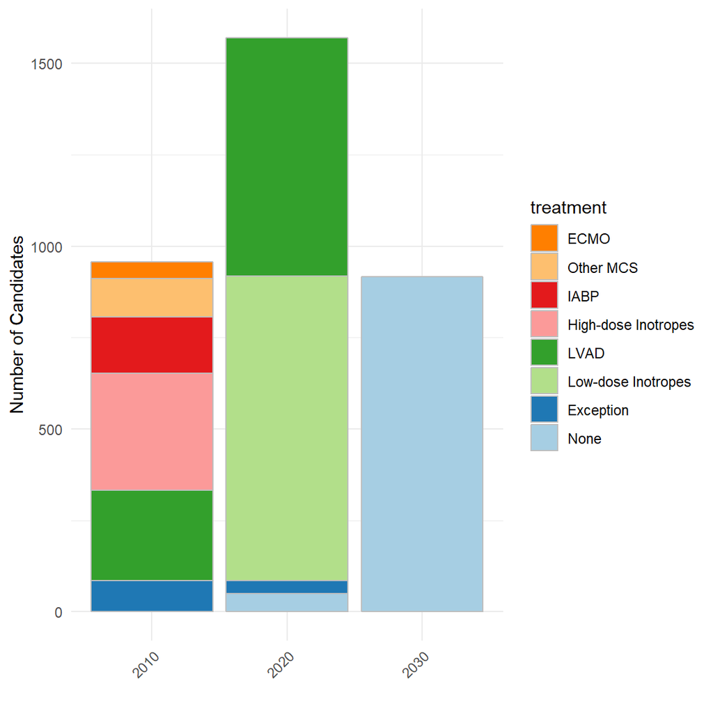

```r
final_sample %>%
  filter(CAN_INIT_STAT < 2100) %>%
  mutate(treatment = factor(treatment,
                            levels = c("ECMO", "Other MCS",
                                       "IABP","High-dose Inotropes",
                                       "LVAD", "Low-dose Inotropes",
                                       "Exception", "None"))) %>%
  ggplot(aes(x = factor(CAN_INIT_STAT), fill = treatment)) +
  geom_bar(color = "grey") +
  labs(
    x = "",
    y = "Number of Candidates") +
  scale_fill_brewer(palette="Paired", direction = -1) +
  theme_minimal() +
    theme(axis.text.x = element_text(angle = 45, hjust = 1))
```

Looks like the treatment codings are appropriate for the Pre-policy status.

### listings by month

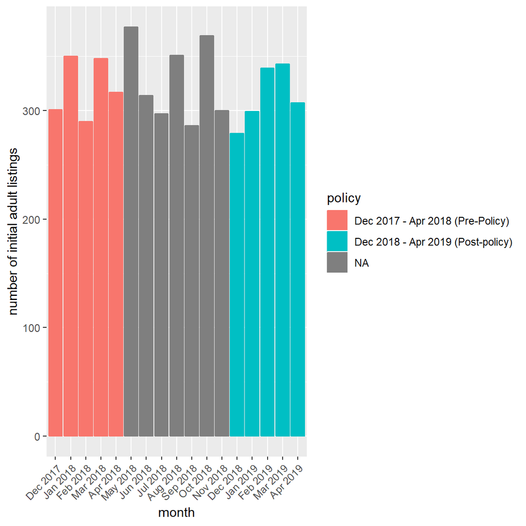

```r
final_sample %>%
  mutate(month = zoo::as.yearmon(list_date)) %>%
ggplot(aes(x = as.factor(month), fill = policy, color = policy )) +
  geom_bar() +
  labs(x = "month", y = "number of initial adult listings") +
  theme(axis.text.x = element_text(angle = 45, hjust = 1))
```

Separation of cohorts is clear

## Write out clean csv file for analysis

```r
write_csv(final_sample, "final_sample.csv")
```

## Comparing timing of registration and justification forms to see if there is a delay in submission of these forms.

```r
just_1a_1bCompare <- just_1a_1b %>%
  select(PX_ID, CANHX_CHG_DT)

new_post_policy_listsCompare <- new_post_policy_lists %>%
  select(PX_ID, BeginDate)

final_sampleComparePRE <- final_sample %>%
  left_join(just_1a_1bCompare, by = "PX_ID") %>%
  select(PX_ID, policy, CAN_INIT_STAT, list_date, CANHX_CHG_DT) %>%
  filter(policy == "Dec 2017 - Apr 2018 (Pre-Policy)") %>%
  count(list_date == CANHX_CHG_DT)

final_sampleComparePOST <- final_sample %>%
  left_join(just_1a_1bCompare, by = "PX_ID") %>%
  left_join(new_post_policy_listsCompare, by = "PX_ID") %>%
  select(PX_ID, policy, list_date, BeginDate, CANHX_CHG_DT) %>%
  filter(policy == "Dec 2018 - Apr 2019 (Post-policy)")

final_sampleComparePOST$BeginDate <- as.Date(final_sampleComparePOST$BeginDate, format = "%Y-%m-%d")

final_sampleComparePOST <- final_sampleComparePOST %>%
  count(list_date == BeginDate)
```

The count of the number of rows that have the same registration and justification form date is calcuolated in the code above. 100% of the listings have the same day of submission. The only exception is that status 2 in the old priority system did not have a justifcation form, so there are no matches for those listings.

## Counting the number of inactives

```r
inactivesCount <- cand_thor %>%
  mutate(list_date = CAN_LISTING_DT) %>%
    filter(list_date >= start_date & list_date <= end_date & WL_ORG == "HR")  %>%
  mutate(status = CAN_INIT_STAT,
         OPO = CAN_LISTING_OPO_ID,
         date_start = list_date)

#remove peds
if (peds == FALSE){
    init_list <- init_list %>% filter(CAN_AGE_AT_LISTING >17)
    tot_adults <- nrow(init_list)
}

#keep multiorgan recipients
if (multi == FALSE){

    multi_recips <- tx_hr %>% filter(REC_TX_TY == 2 | REC_TX_TY ==4) %>% select(PX_ID,REC_TX_TY)

    n_mults <- nrow(init_list %>% filter(PX_ID %in% multi_recips$PX_ID))

    init_list <- init_list %>% filter(!PX_ID %in% multi_recips$PX_ID)

    remove(multi_recips)
}

inactivesCountPre <- inactivesCount %>%
  select(list_date, CAN_INIT_STAT) %>%
  filter(list_date >= "2017-12-1") %>%
  filter(list_date < "2018-5-01") %>%
  count(CAN_INIT_STAT)

inactivesCountPost <- inactivesCount %>%
  select(list_date, CAN_INIT_STAT) %>%
  filter(list_date >= "2018-12-1") %>%
  filter(list_date < "2019-5-01") %>%
  count(CAN_INIT_STAT)
```

There are 60 inactive listings in the pre policy cohort and 51 in the post policy cohort.

Code by Kevin Chung and William Parker

*William.Parker@uchospitals.edu*

*Kevin.Chung@uchospitals.edu*